# 📌 Problem Statement

Which customer segments drive the most revenue and how can we target them effectively?

# E‑commerce RFM & CLV Analysis 📊

**Objective**  
Identify high‑value customer segments and quantify revenue potential using RFM scoring and 12‑month Customer Lifetime Value (CLV) estimates.  
Outputs include actionable insights for retention, upselling, and acquisition.

## Notebook Roadmap

1. **Setup & Imports**
2. **Data Loading & Cleaning**
3. **RFM Feature Engineering**
4. **CLV Modeling**
5. **Segmentation & Visualization**
6. **Insights & Business Recommendations**

# Project Description

**Which customer segments drive the most revenue and lifetime value, and how can we identify and target these high-value cohorts effectively?**

Understanding which customer segments drive the most revenue and lifetime value is an indicator of which products are serving the needs of the customer the best.

- How many times a customer will make a purchase in the future (frequency prediction)
- How recently they've purchased (recency)
- How long you've observed them (T, the age of the customer)
- Segmenting customers into personas to find the most profitable users

# Data Cleaning and Pre-processing

# 🗂 Data Overview

|  | InvoiceNo | StockCode | Description | Quantity | InvoiceDate | UnitPrice | CustomerID | Country |
| --- | --- | --- | --- | --- | --- | --- | --- | --- |
| 0 | 536365 | 85123A | WHITE HANGING HEART T-LIGHT HOLDER | 6 | 12/1/2010 8:26 | 2.55 | 17850.0 | United Kingdom |
| 1 | 536365 | 71053 | WHITE METAL LANTERN | 6 | 12/1/2010 8:26 | 3.39 | 17850.0 | United Kingdom |
| 2 | 536365 | 84406B | CREAM CUPID HEARTS COAT HANGER | 8 | 12/1/2010 8:26 | 2.75 | 17850.0 | United Kingdom |
| 3 | 536365 | 84029G | KNITTED UNION FLAG HOT WATER BOTTLE | 6 | 12/1/2010 8:26 | 3.39 | 17850.0 | United Kingdom |
| 4 | 536365 | 84029E | RED WOOLLY HOTTIE WHITE HEART. | 6 | 12/1/2010 8:26 | 3.39 | 17850.0 | United Kingdom |

```
########### Head ###########
  InvoiceNo StockCode                          Description  Quantity  \
0    536365    85123A   WHITE HANGING HEART T-LIGHT HOLDER         6
1    536365     71053                  WHITE METAL LANTERN         6
2    536365    84406B       CREAM CUPID HEARTS COAT HANGER         8
3    536365    84029G  KNITTED UNION FLAG HOT WATER BOTTLE         6
4    536365    84029E       RED WOOLLY HOTTIE WHITE HEART.         6

      InvoiceDate  UnitPrice  CustomerID         Country
0  12/1/2010 8:26       2.55     17850.0  United Kingdom
1  12/1/2010 8:26       3.39     17850.0  United Kingdom
2  12/1/2010 8:26       2.75     17850.0  United Kingdom
3  12/1/2010 8:26       3.39     17850.0  United Kingdom
4  12/1/2010 8:26       3.39     17850.0  United Kingdom
########### Tail ###########
       InvoiceNo StockCode                      Description  Quantity  \
541904    581587     22613      PACK OF 20 SPACEBOY NAPKINS        12
541905    581587     22899     CHILDREN'S APRON DOLLY GIRL          6
541906    581587     23254    CHILDRENS CUTLERY DOLLY GIRL          4
541907    581587     23255  CHILDRENS CUTLERY CIRCUS PARADE         4
541908    581587     22138    BAKING SET 9 PIECE RETROSPOT          3

            InvoiceDate  UnitPrice  CustomerID Country
541904  12/9/2011 12:50       0.85     12680.0  France
541905  12/9/2011 12:50       2.10     12680.0  France
541906  12/9/2011 12:50       4.15     12680.0  France
541907  12/9/2011 12:50       4.15     12680.0  France
541908  12/9/2011 12:50       4.95     12680.0  France
########### Shape ###########
(541909, 8)
########### Info ###########
<class 'pandas.core.frame.DataFrame'>
RangeIndex: 541909 entries, 0 to 541908
Data columns (total 8 columns):
 #   Column       Non-Null Count   Dtype
---  ------       --------------   -----
 0   InvoiceNo    541909 non-null  object
 1   StockCode    541909 non-null  object
 2   Description  540455 non-null  object
 3   Quantity     541909 non-null  int64
```

[output cut: 17 more lines]

```
                 75%      max
Quantity       10.00  80995.0
UnitPrice       4.13  38970.0
CustomerID  16791.00  18287.0
########### NA ###########
InvoiceNo           0
StockCode           0
Description      1454
Quantity            0
InvoiceDate         0
UnitPrice           0
CustomerID     135080
Country             0
dtype: int64
None
```

**Column Descritpions:**

InvoiceNo: Invoice number that consists 6 digits. If this code starts with letter 'c', it indicates a cancellation.

StockCode: Product code that consists 5 digits.

Description: Product name.

Quantity: The quantities of each product per transaction.

InvoiceDate: Represents the day and time when each transaction was generated.

UnitPrice: Product price per unit in sterling (Â£).

CustomerID: Customer number that consists 5 digits. Each customer has a unique customer ID.

Country: Name of the country where each customer resides.

### Finding Complete Rows which are complete duplicates:

# 🧹 Data Cleaning & Preprocessing

[output not shown]

|  | invoice_no | stock_code | description | quantity | invoice_date | unit_price | customer_id | country |
| --- | --- | --- | --- | --- | --- | --- | --- | --- |
| 0 | 536365 | 85123A | WHITE HANGING HEART T-LIGHT HOLDER | 6 | 12/1/2010 8:26 | 2.55 | 17850.0 | United Kingdom |
| 1 | 536365 | 71053 | WHITE METAL LANTERN | 6 | 12/1/2010 8:26 | 3.39 | 17850.0 | United Kingdom |
| 2 | 536365 | 84406B | CREAM CUPID HEARTS COAT HANGER | 8 | 12/1/2010 8:26 | 2.75 | 17850.0 | United Kingdom |
| 3 | 536365 | 84029G | KNITTED UNION FLAG HOT WATER BOTTLE | 6 | 12/1/2010 8:26 | 3.39 | 17850.0 | United Kingdom |
| 4 | 536365 | 84029E | RED WOOLLY HOTTIE WHITE HEART. | 6 | 12/1/2010 8:26 | 3.39 | 17850.0 | United Kingdom |
| ... | ... | ... | ... | ... | ... | ... | ... | ... |
| 541904 | 581587 | 22613 | PACK OF 20 SPACEBOY NAPKINS | 12 | 12/9/2011 12:50 | 0.85 | 12680.0 | France |
| 541905 | 581587 | 22899 | CHILDREN'S APRON DOLLY GIRL | 6 | 12/9/2011 12:50 | 2.10 | 12680.0 | France |
| 541906 | 581587 | 23254 | CHILDRENS CUTLERY DOLLY GIRL | 4 | 12/9/2011 12:50 | 4.15 | 12680.0 | France |
| 541907 | 581587 | 23255 | CHILDRENS CUTLERY CIRCUS PARADE | 4 | 12/9/2011 12:50 | 4.15 | 12680.0 | France |
| 541908 | 581587 | 22138 | BAKING SET 9 PIECE RETROSPOT | 3 | 12/9/2011 12:50 | 4.95 | 12680.0 | France |

401604 rows × 8 columns

## Visualising Descriptive Statistics and Interquartile Range

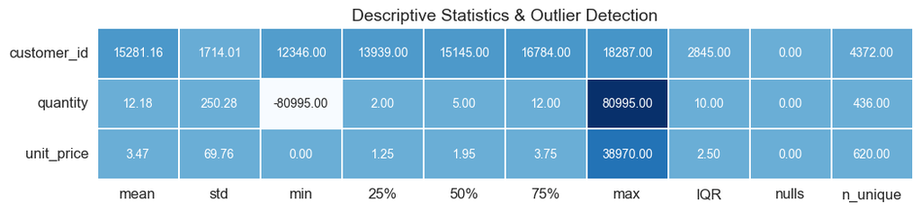

## Inferences:

Quantity:

1. Average Quantity per transaction is around 12 units.
2. std is relatively large at around 250 units per transaction. 3.**Quantity min is showing negative values meaning that a negative quanity of products were purchased - this could indicate a return from the customer or potential canceled orders**
3. IQR is 10 units
4. **max value is unrealistically higher than the IQR - this is abnormally large**

Unit Price:

1. Average unit price was 3.46
2. std at around 70 GBP
3. **Min is 0** this indicates unrealistic outliers- this could indicate promotional items such as giveaways.
4. **Should we eliminate the large max value ?** this could be helpful to our analysis ?
5. There are 620 unique unit prices - wholesale dataset

Customer ID:

1. There are 4372 unique customers

Considerations:

1. Quantity - Cap Values
2. Unit - Cap Values
3. **Investigate the Order numbers marked with C to describe canceled orders**

```
Total rows: 392,732
Distinct invoices: 18,536
```

### 📦 Build Customer-Level Summary Table

This function transforms raw invoice-level transaction data into **customer-level aggregates** for use in RFM scoring and CLV modeling.

**What it does:**

- Converts the `invoice_date` column to datetime format for accurate date math.
- Calculates `line_total` for each row as `unit_price × quantity`.
- Identifies the most recent purchase date in the dataset to compute **recency**.
- Groups by `customer_id` to compute the following features:
  - 🧾 `orders`: number of unique invoices (proxy for purchase frequency).
  - 🗓️ `first_date`, `last_date`: customer’s first and most recent purchase dates.
  - 💰 `monetary`: total spend across all orders.
  - 📊 `avg_order_value`: average basket size per transaction.
  - 🌍 `country`: preserved as-is (first observed country per customer).
- Derives:
  - 📅 `recency`: days since the last purchase.
  - 🔁 `frequency`: number of distinct orders.
  - ⏳ `obs_months`: time span (in months) between first and last purchase, clipped at minimum of 1 to avoid division issues.

**Why it's important:** This table condenses raw transactional logs into a **compact customer view** that feeds directly into:

- 📐 RFM scoring logic
- 📈 CLV predictive models
- 📦 Customer segmentation

**Returns:** A DataFrame with one row per customer and engineered fields that describe their purchase behavior.

# 🔁 Feature Engineering: RFM Metrics

### 🧮 Compute RFM Scores and Estimate 12-Month CLV

This function takes a **customer-level summary DataFrame** and enhances it with:

1. **RFM Scores** (Recency, Frequency, Monetary)
2. A **12-month CLV estimate** using a simplified revenue projection formula.

**What it does:**

#### 🔢 RFM Scoring

- **Recency Score**: Lower recency (i.e., more recent activity) is better. Customers are ranked into 5 quantiles (`pd.qcut` on `-recency`).
- **Frequency Score**: Higher number of orders = higher score.
- **Monetary Score**: Total amount spent across all purchases.

- ✅ Adds a new column `rfm_total` = sum of all three scores.
- 🎯 Used to rank customers and segment them (e.g., into “Champions”, “At-Risk”, etc.)

#### 💸 CLV Estimate

Calculates **12-month Customer Lifetime Value (CLV)** using a basic revenue projection formula This gives an expected value from each customer over the next year based on their past behavior.

**Why it's important:**

- 🎯 **RFM scores** help with segmentation, targeting, and prioritizing customer retention efforts.
- 📈 **CLV** predicts future revenue potential, useful for ROI-driven marketing and strategic planning.

**Returns:** The original customer-level DataFrame with five new columns:

- `recency_score`
- `frequency_score`
- `monetary_score`
- `rfm_total`
- `clv_12mo` (rounded to 2 decimals)

# 📈 CLV Estimation

|  | customer_id | orders | first_date | last_date | monetary | avg_order_value | country | recency | frequency | obs_months | recency_score | frequency_score | monetary_score | rfm_total | clv_12mo |
| --- | --- | --- | --- | --- | --- | --- | --- | --- | --- | --- | --- | --- | --- | --- | --- |
| 0 | 12346.0 | 1 | 2011-01-18 10:01:00 | 2011-01-18 10:01:00 | 77183.60 | 77183.600000 | United Kingdom | 325 | 1 | 1.000000 | 1 | 1 | 5 | 7 | 926203.20 |
| 1 | 12347.0 | 7 | 2010-12-07 14:57:00 | 2011-12-07 15:52:00 | 4310.00 | 23.681319 | Iceland | 1 | 7 | 12.166667 | 5 | 4 | 5 | 14 | 163.50 |
| 2 | 12348.0 | 4 | 2010-12-16 19:09:00 | 2011-09-25 13:13:00 | 1797.24 | 57.975484 | Finland | 74 | 4 | 9.400000 | 2 | 3 | 4 | 9 | 296.05 |
| 3 | 12349.0 | 1 | 2011-11-21 09:51:00 | 2011-11-21 09:51:00 | 1757.55 | 24.076027 | Italy | 18 | 1 | 1.000000 | 4 | 1 | 4 | 9 | 288.91 |
| 4 | 12350.0 | 1 | 2011-02-02 16:01:00 | 2011-02-02 16:01:00 | 334.40 | 19.670588 | Norway | 309 | 1 | 1.000000 | 1 | 1 | 2 | 4 | 236.05 |
| ... | ... | ... | ... | ... | ... | ... | ... | ... | ... | ... | ... | ... | ... | ... | ... |
| 4334 | 18280.0 | 1 | 2011-03-07 09:52:00 | 2011-03-07 09:52:00 | 180.60 | 18.060000 | United Kingdom | 277 | 1 | 1.000000 | 1 | 1 | 1 | 3 | 216.72 |
| 4335 | 18281.0 | 1 | 2011-06-12 10:53:00 | 2011-06-12 10:53:00 | 80.82 | 11.545714 | United Kingdom | 180 | 1 | 1.000000 | 1 | 1 | 1 | 3 | 138.55 |
| 4336 | 18282.0 | 2 | 2011-08-05 13:35:00 | 2011-12-02 11:43:00 | 178.05 | 14.837500 | United Kingdom | 7 | 2 | 3.933333 | 5 | 1 | 1 | 7 | 90.53 |
| 4337 | 18283.0 | 16 | 2011-01-06 14:14:00 | 2011-12-06 12:02:00 | 2045.53 | 2.837074 | United Kingdom | 3 | 16 | 11.100000 | 5 | 4 | 4 | 13 | 49.07 |
| 4338 | 18287.0 | 3 | 2011-05-22 10:39:00 | 2011-10-28 09:29:00 | 1837.28 | 26.246857 | United Kingdom | 42 | 3 | 5.266667 | 3 | 2 | 4 | 9 | 179.41 |

4339 rows × 15 columns

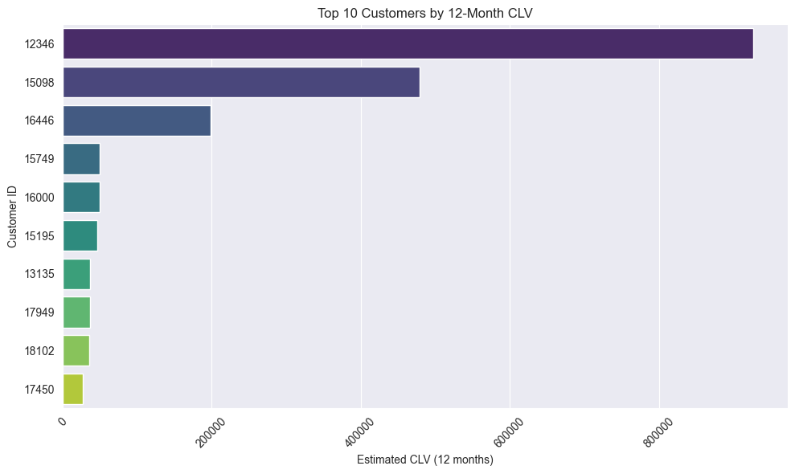

### 🔍 What the Chart Shows

1. The **X-axis** represents estimated **Customer Lifetime Value (CLV)** over the next 12 months — i.e., how much revenue each customer is expected to generate.
2. The **Y-axis** shows the **Customer IDs** of your top 10 highest-value customers.
3. The **height of each bar** corresponds to the customer’s projected revenue, allowing for easy comparison of value contribution across the top cohort.

### 💡 Insights from CLV Analysis

#### 3. Strategic Marketing Insight

- Targeted retention efforts for the **top 10 customers** can lead to **significant revenue uplift**.
- You can build a **lookalike segment** by analyzing behavior patterns of these high-value users:
  - Purchase frequency
  - Product preferences
  - Engagement channels

### Plot 2: RFM Heatmap (Frequency vs. Recency by Monetary)

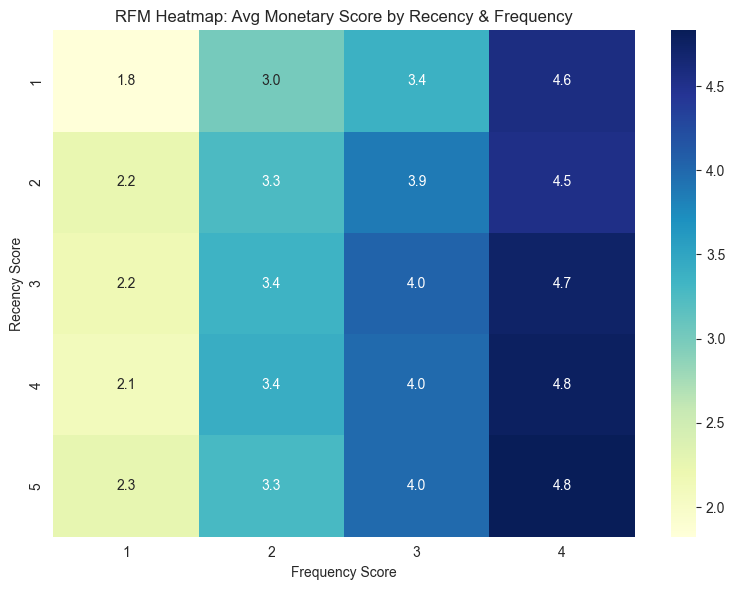

### 📊 Boxplots of RFM Features

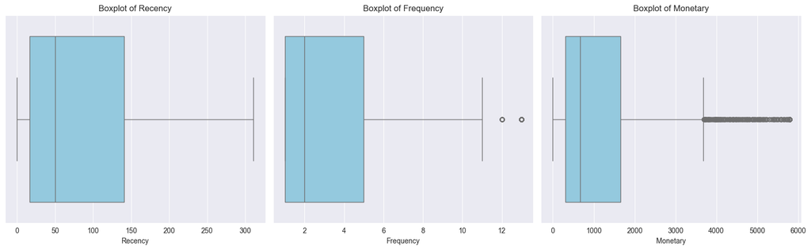

This chart provides a quick visual summary of the **distribution and spread** of the three core RFM metrics across customers:

- **Recency** (days since last purchase)
- **Frequency** (number of orders)
- **Monetary** (total spend)

**What to look for:**

- The **box** shows the interquartile range (middle 50% of customers).
- **Lines** extending from the box show the overall spread (min/max, excluding outliers).
- **Dots** are potential outliers—often your top spenders or most frequent buyers.

These plots help identify skewed distributions and outliers that may influence clustering or CLV calculations.

### 🎯 Segment Customers by Value & Behavior

This section uses a rule-based function to assign customers into meaningful business segments based on their RFM score and predicted 12-month CLV.

Defined segments:

- **Gold Loyalists**: High RFM + High CLV
- **Silver Steady**: Medium RFM + High CLV
- **Bronze Bargain-Hunters**: Low RFM
- **At-Risk**: Low RFM and CLV

This allows us to group customers for targeted retention and acquisition strategies.

# 🧠 Customer Segmentation

# 🌍 Segment Distribution by Country

|  | country | segment | customer_count |
| --- | --- | --- | --- |
| 0 | Australia | Bronze Bargain-Hunters | 5 |
| 1 | Australia | At-Risk | 2 |
| 2 | Australia | Gold Loyalists | 2 |
| 3 | Austria | Bronze Bargain-Hunters | 4 |
| 4 | Austria | At-Risk | 3 |
| ... | ... | ... | ... |
| 88 | United Kingdom | Bronze Bargain-Hunters | 1667 |
| 89 | United Kingdom | At-Risk | 1601 |
| 90 | United Kingdom | Gold Loyalists | 354 |
| 91 | United Kingdom | Silver Steady | 299 |
| 92 | Unspecified | Bronze Bargain-Hunters | 4 |

93 rows × 3 columns

|  | country | segment | customer_count |
| --- | --- | --- | --- |
| 90 | United Kingdom | Gold Loyalists | 354 |
| 39 | Germany | Gold Loyalists | 18 |
| 35 | France | Gold Loyalists | 13 |
| 61 | Norway | Gold Loyalists | 3 |
| 30 | Finland | Gold Loyalists | 3 |
| 48 | Italy | Gold Loyalists | 3 |
| 79 | Sweden | Gold Loyalists | 2 |
| 76 | Spain | Gold Loyalists | 2 |
| 68 | Portugal | Gold Loyalists | 2 |
| 2 | Australia | Gold Loyalists | 2 |
| 26 | EIRE | Gold Loyalists | 2 |
| 51 | Japan | Gold Loyalists | 2 |
| 59 | Netherlands | Gold Loyalists | 1 |
| 10 | Belgium | Gold Loyalists | 1 |
| 72 | Singapore | Gold Loyalists | 1 |
| 17 | Channel Islands | Gold Loyalists | 1 |
| 83 | Switzerland | Gold Loyalists | 1 |

### 📌 Interpretation: Segment Distribution by Country

The `segment_summary` table reveals how different customer segments are distributed across countries.

- The **United Kingdom** has by far the highest concentration of **Gold Loyalists** (354 customers), making it the most valuable market for retention and loyalty efforts.
- Other notable countries with high-value customers include **Germany**, **France**, and **Finland**, albeit in much smaller volumes.
- Segments like **At-Risk** and **Bronze Bargain-Hunters** are also present in multiple regions, which may indicate churn risk or low spending potential.

**Business Insight:** You can use this segmentation to drive **geo-targeted marketing strategies**, focusing loyalty programs and personalized engagement on countries with the highest density of high-CLV customers.

### 📊 Unsupervised Clustering of Customers (RFM Segmentation)

This project applied **KMeans clustering** to **RFM data** (Recency, Frequency, Monetary) to uncover customer segments. The workflow included feature engineering, transformation, clustering, dimensionality reduction, and segment interpretation.

**✅ RFM Features Defined:**

- **Recency**: Days since the customer's last purchase
- **Frequency**: Total number of transactions
- **Monetary**: Total revenue generated per customer

**🧪 Data Transformation:**

- Features were **standardized** and **log-transformed** to ensure comparability and reduce skewness in distribution.

**🔍 Clustering Approach:**

- **KMeans** clustering was used to group customers into distinct segments based on purchasing behavior.
- The algorithm works by minimizing within-cluster variance to find natural groupings.

**📉 Dimensionality Reduction:**

- **PCA (Principal Component Analysis)** was applied to project the 3D RFM data into 2D space.
- This allowed for effective visualization of customer clusters.

**🎯 Segment Interpretation:**

- Clusters were labeled into marketing-relevant personas, such as:
  - *At-Risk Value*
  - *High-Spending Sleepers*
  - *Loyal Frequent Buyers*

This segmentation can inform targeted marketing strategies and customer retention efforts.

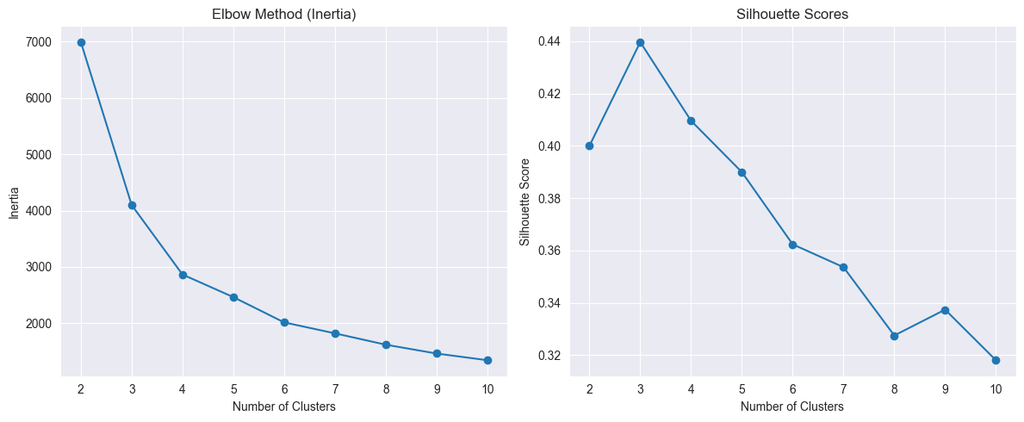

|  | cluster | recency | frequency | monetary | num_customers |
| --- | --- | --- | --- | --- | --- |
| 0 | 0 | 49.410357 | 2.371628 | 6.331832 | 2298 |
| 1 | 1 | 24.063701 | 8.789687 | 8.037663 | 989 |
| 2 | 2 | 239.651141 | 1.434411 | 5.620040 | 1052 |

# 🔬 PCA & Clustering

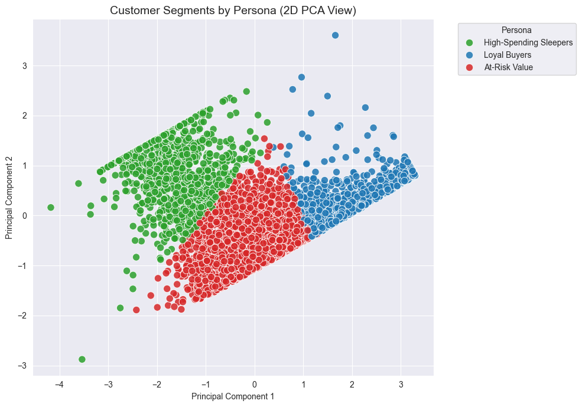

### 🧠 Customer Segmentation Analysis (via PCA)

The scatterplot above presents a 2D Principal Component Analysis (PCA) projection of customers based on their **Recency**, **Frequency**, and **Monetary (RFM)** scores. Each point represents a customer, and colors correspond to persona segments derived from **KMeans clustering**.

#### 📊 Technical Notes:

- **Log transformation** and **outlier capping** were applied before PCA to reduce skewness and enhance cluster integrity.
- **3 clusters** were chosen based on a balance of the **elbow method** and **silhouette scores**.

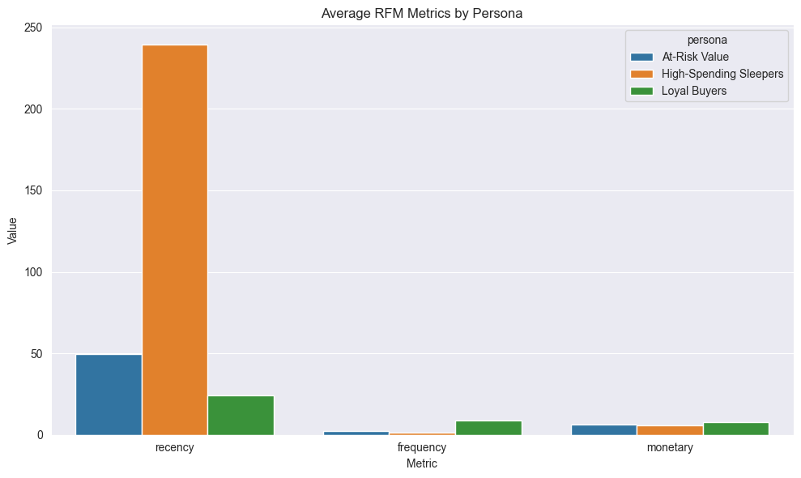

### 📊 Interpreting RFM Averages by Customer Segment

This chart visualizes the **average RFM metrics**—Recency, Frequency, and Monetary value—for each of the customer segments discovered through clustering.

Each bar represents the **average value** of one metric for one customer persona:

#### 🔍 Metrics Explained:

- **Recency**: Days since the customer's last purchase (⚠️ lower is better)
- **Frequency**: Total number of purchases (✅ higher is better)
- **Monetary**: Total revenue generated by the customer (✅ higher is better)

### 🧠 Segment Insights:

#### ✅ **Loyal Buyers**

- **Low Recency** → These customers purchased recently.
- **High Frequency** → They make repeat purchases often.
- **High Monetary Value** → They spend a lot annually.
- 🔑 **Insight**: This is the company’s most engaged and profitable segment. Marketing teams should prioritize loyalty programs and upsell strategies for them.

### 🎯 Why It Matters:

This visualization helps marketing teams:

- Personalize campaigns for each persona.
- Allocate resources toward high-impact customer groups.
- Design retention and reactivation strategies based on behavioral traits.

# 🧠 Insights & Recommendations

**Insights**

- Gold Loyalists drive the highest revenue despite being a small segment.
- At-Risk customers are widespread and show signs of churn.
- The Pareto Principle holds — a minority of users generate most value.

**Recommendations**

- Prioritize loyalty perks for high-CLV segments.
- Retarget At-Risk users with personalized offers.
- Use top-performer traits to acquire lookalike customers.